# STA 106 - Project 1

## Fruits

This is to check if participants eat at least one fruit per day.

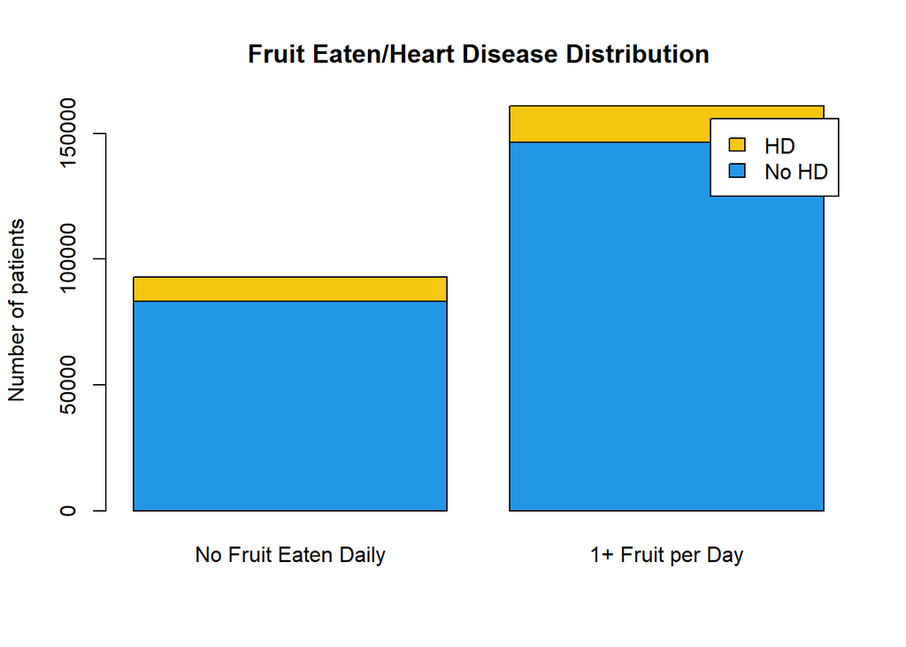

```r
fruit <- xtabs(~HeartDiseaseorAttack+Fruits, data = hd)
rownames(fruit) <- c("No HD", "HD")
colnames(fruit) <- c("No Fruit Eaten Daily", "1+ Fruit per Day")


barplot(fruit, legend.text = TRUE, main = "Fruit Eaten/Heart Disease Distribution", ylab = "Number of patients", col = c(4,7))
```

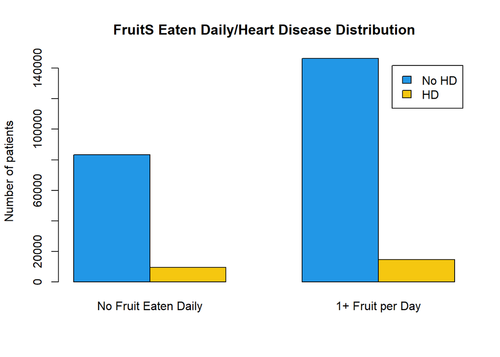

```r
barplot(fruit, legend.text = TRUE, beside = TRUE, main = "FruitS Eaten Daily/Heart Disease Distribution", ylab = "Number of patients", col = c(4,7))
```

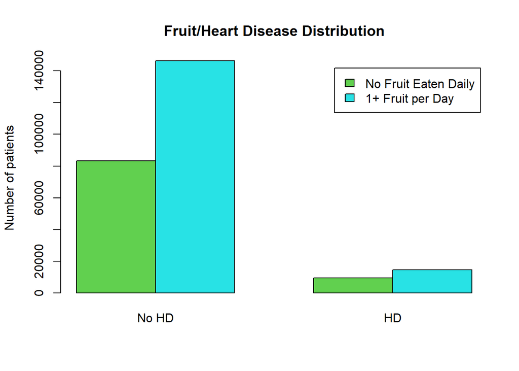

```r
barplot(t(fruit), legend.text = TRUE, beside = TRUE, main = "Fruit/Heart Disease Distribution", ylab = "Number of patients", col = c(3,5))
```

```r
fruit_percentage <- prop.table(fruit ,margin =1)[2,]
fruit_percentage
```

```
## No Fruit Eaten Daily     1+ Fruit per Day
##            0.3953041            0.6046959
```

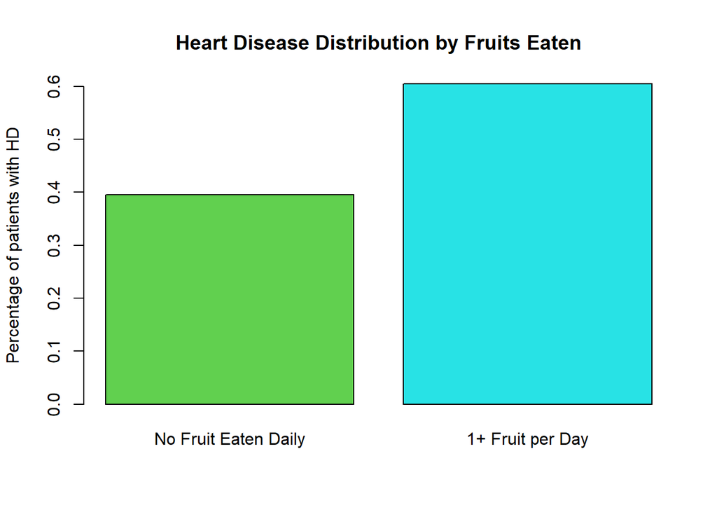

```r
#Interestingly, 60% of people with heart disease eat at least one fruit every day.The numbers are pretty closely related, indicating to me that this largely isn't a big determinant of heart disease/heart attacks.

barplot(fruit_percentage, main = "Heart Disease Distribution by Fruits Eaten", ylab = "Percentage of patients with HD", col = c(3,5))
```

```r
#Now, we will calculate the full odd ratio and place it into our overall table for categorical variables. This time, we will calculate the odds in reverse as we want to look at how likely it is for someone who does not exercise regularly to get heart problems.

fruit_odds = fruit
fruit_odds=rbind(fruit_odds, 'Odds'=round(fruit_odds[2,]/fruit_odds[1,],2))
fruit_odds=rbind(fruit_odds, 'Odds Ratio'=c(round(fruit_odds[3,1]/fruit_odds[3,2],2),0))

#From this, we now know that people who do not eat at least one fruit a day are 1.1x more likely to have heart problems than those who do not.

cat_vars["Fruits"] = 1.1
```

## Veggies

This is to examine patients that do not eat at least one vegetable per day and their likelihood of contracting heart problems.

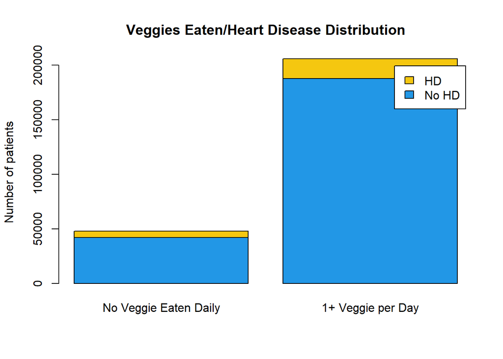

```r
veggie <- xtabs(~HeartDiseaseorAttack+Veggies, data = hd)
rownames(veggie) <- c("No HD", "HD")
colnames(veggie) <- c("No Veggie Eaten Daily", "1+ Veggie per Day")


barplot(veggie, legend.text = TRUE, main = "Veggies Eaten/Heart Disease Distribution", ylab = "Number of patients", col = c(4,7))
```

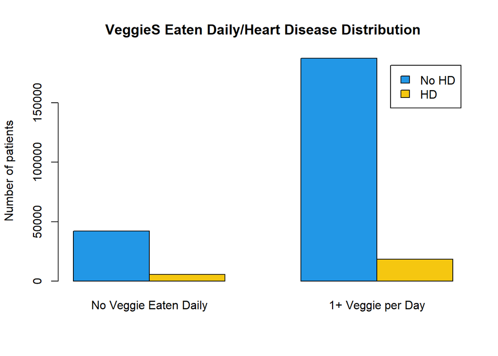

```r
barplot(veggie, legend.text = TRUE, beside = TRUE, main = "VeggieS Eaten Daily/Heart Disease Distribution", ylab = "Number of patients", col = c(4,7))
```

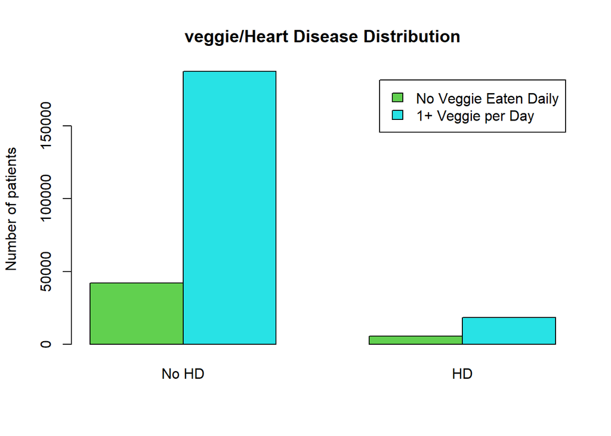

```r
barplot(t(veggie), legend.text = TRUE, beside = TRUE, main = "veggie/Heart Disease Distribution", ylab = "Number of patients", col = c(3,5))
```

```r
veggie_percentage <- prop.table(veggie,margin =1)[2,]
veggie_percentage
```

```
## No Veggie Eaten Daily     1+ Veggie per Day
##             0.2360943             0.7639057
```

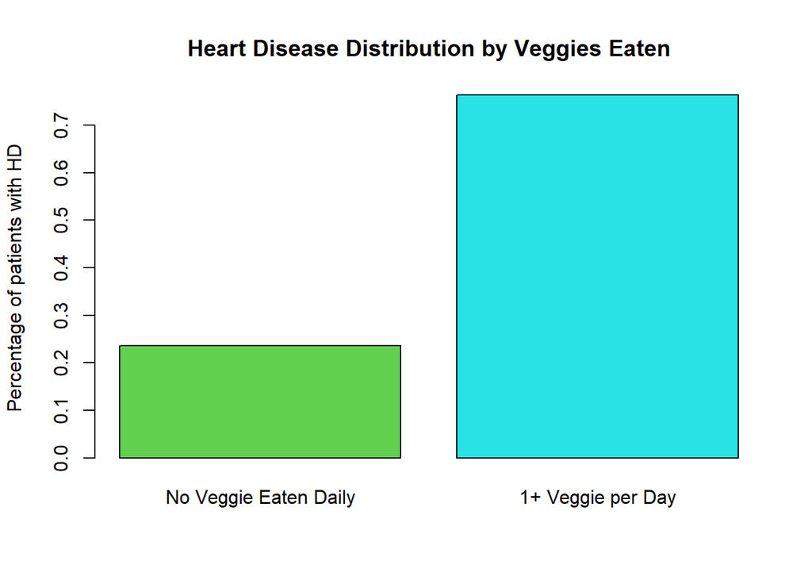

```r
#Interestingly, 76.4% of people with heart disease eat at least one veggie every day.

barplot(veggie_percentage, main = "Heart Disease Distribution by Veggies Eaten", ylab = "Percentage of patients with HD", col = c(3,5))
```

```r
#Now, we will calculate the full odd ratio and place it into our overall table for categorical variables. This time, we will calculate the odds in reverse as we want to look at how likely it is for someone who does not eat vegetables to get heart problems.

veggie_odds = veggie
veggie_odds=rbind(veggie_odds, 'Odds'=round(veggie_odds[2,]/veggie_odds[1,],2))
veggie_odds=rbind(veggie_odds, 'Odds Ratio'=c(round(veggie_odds[3,1]/veggie_odds[3,2],2),0))

#From this, we now know that people who do not eat at least one veggie a day are 1.3x more likely to have heart problems than those who do not.
cat_vars["Veggies"] = 1.3
```

## Heavy Alcohol Consumption

In the data set, this is defined as adult men having more than 14 drinks per week and adult women having more than 7 drinks per week.

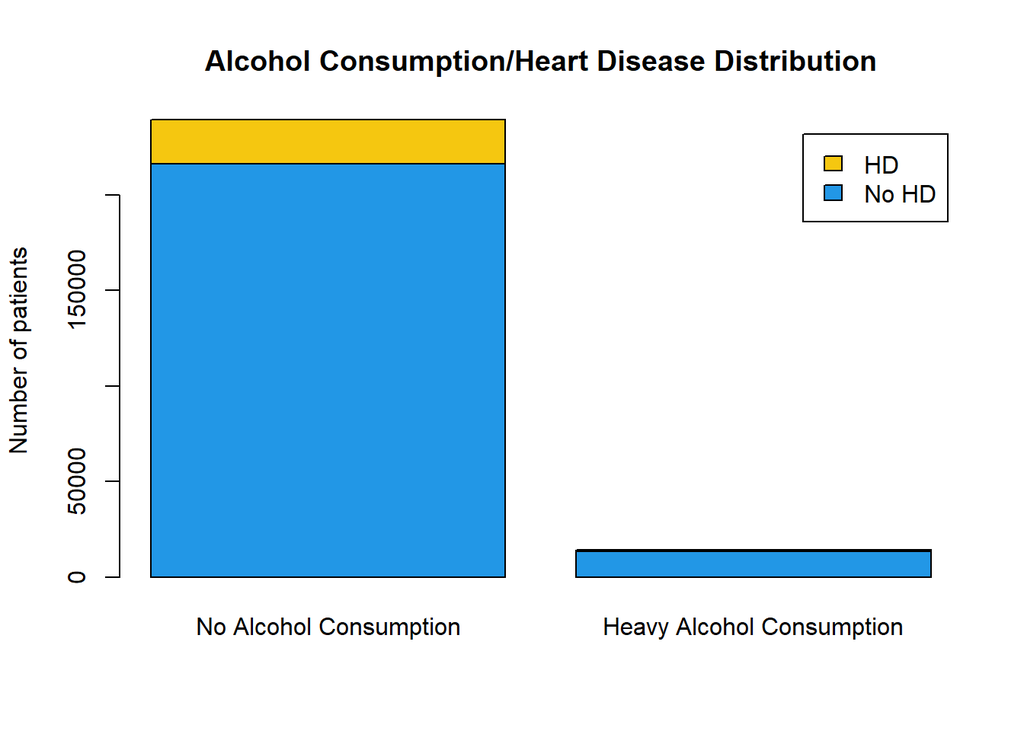

```r
alc <- xtabs(~HeartDiseaseorAttack+HvyAlcoholConsump, data = hd)
rownames(alc) <- c("No HD", "HD")
colnames(alc) <- c("No Alcohol Consumption", "Heavy Alcohol Consumption")


barplot(alc, legend.text = TRUE, main = "Alcohol Consumption/Heart Disease Distribution", ylab = "Number of patients", col = c(4,7))
```

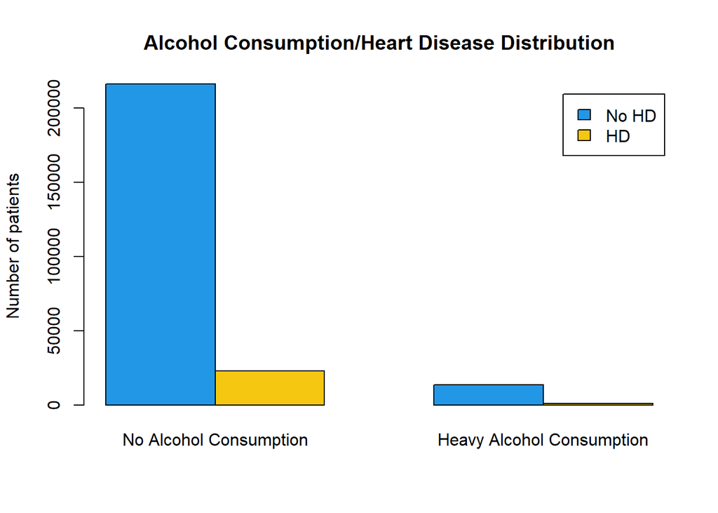

```r
barplot(alc, legend.text = TRUE, beside = TRUE, main = "Alcohol Consumption/Heart Disease Distribution", ylab = "Number of patients", col = c(4,7))
```

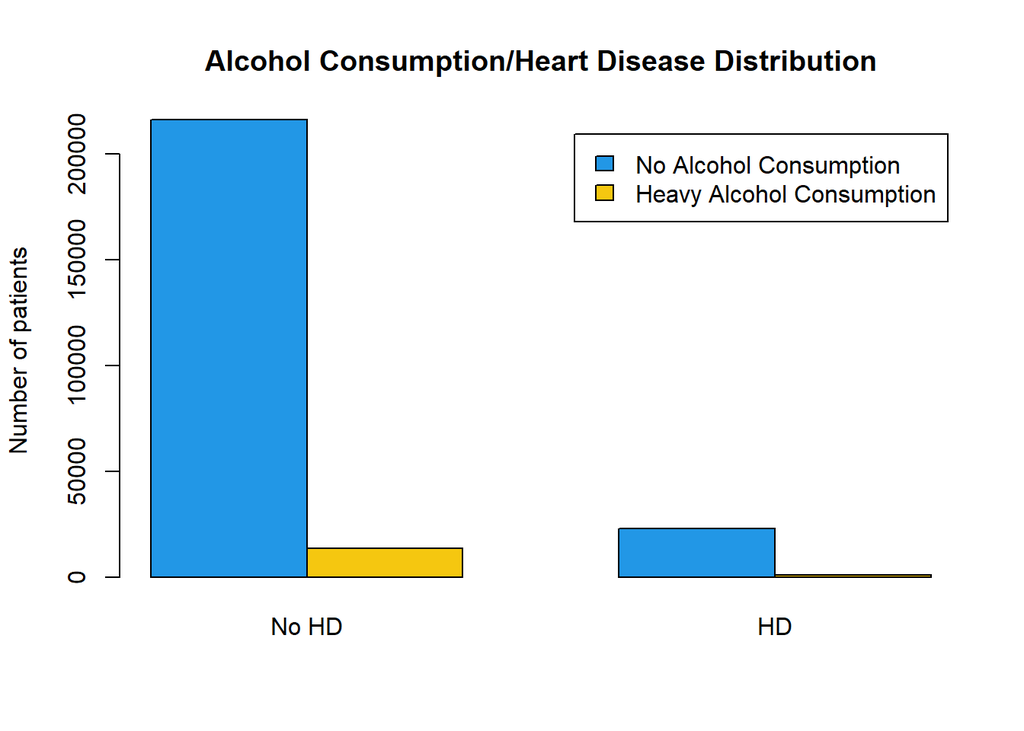

```r
barplot(t(alc), legend.text = TRUE, beside = TRUE, main = "Alcohol Consumption/Heart Disease Distribution", ylab = "Number of patients", col = c(4,7))
```

```r
alc_percentage <- prop.table(alc,margin =1)[2,]
alc_percentage
```

```
##    No Alcohol Consumption Heavy Alcohol Consumption
##                0.96450843                0.03549157
```

```r
#Interestingly, 96.45% of people with heart disease do not drink heavily.

alc_odds = alc
alc_odds=rbind(alc_odds, 'Odds'=round(alc_odds[2,]/alc_odds[1,],2))
alc_odds=rbind(alc_odds, 'Odds Ratio'=c(round(alc_odds[3,1]/alc_odds[3,2],2),0))

#This odds ratio says that people that do not drink heavily are 1.83 times as likely to have heart problems.
cat_vars["HvyAlcoholConsump"] = 1.83
```